# R Notebook - REU

Jennifer Sailor

7/21/2021

## REU Data for Research Project

```r
library(readr)
PHRS <- read_csv("C:/Users/jans7/OneDrive - lindenwood.edu/REU Internship/Data_for_Reseach_Project_jenny.csv")
View(PHRS)
attach(PHRS)
```

**Questions:**

1. Did coaching length affect PHRS score?
2. Did Coaching length affect BMI score? Sub question: Does the length of a health coaching session matter? I.e.,are longer sessions are associated with better PHRSs? BMI?
3. is bmi and phrs correlated/whats there relationship? Sub question: are there any patterns with gender
4. Are men more likely to participate in health coaching than women? (or women than men?) Are there subcategories (e.g., men with the BMI over 30 are as likely to participate in health coaching as women with the BMI over 30).
5. are men or women more likely to participate in linger amounts of health coaching?
6. Is there a value of BMI at which the likelihood of participating in health coaching increases sharply (I am picturing a hockey stick graph here)? NO
7. Boxplot of BMI and PHRS

**Background** NOTE: (update) in the .csv I made a column that is the difference BMI and PHRS which is the post-pre (was pre-post) thus a positive number would not be good for PHRS vs BMI that would be bad. Also I made a total coaching column which is the amount of times vs the length of session, which should give more accurate information.

```r
#number of people who participated in at least 1 coaching session
sum(PHRS$Coaching > 0, na.rm=TRUE)
```

```
[1] 1310
```

```r
1310 / 9366 * 100
```

```
[1] 13.98676
```

**1. Did coaching affect PHRS score?**

x = total coaching minutes, y = difference phrs

```r
line_1 <- lm(DifferencePHRS ~ TotalCoachingMinutes, data = PHRS)
summary(line_1)
```

```
Call:
lm(formula = DifferencePHRS ~ TotalCoachingMinutes, data = PHRS)

Residuals:
    Min      1Q  Median      3Q     Max
-54.555  -5.481  -0.286   4.519  67.519

Coefficients:
                     Estimate Std. Error t value Pr(>|t|)
(Intercept)          -0.51855    0.11215  -4.624 3.82e-06 ***
TotalCoachingMinutes  0.01789    0.00428   4.180 2.95e-05 ***
---
Signif. codes:  0 ‘***’ 0.001 ‘**’ 0.01 ‘*’ 0.05 ‘.’ 0.1 ‘ ’ 1

Residual standard error: 10.47 on 9365 degrees of freedom
Multiple R-squared:  0.001862,  Adjusted R-squared:  0.001755
F-statistic: 17.47 on 1 and 9365 DF,  p-value: 2.945e-05
```

```r
cor.test(TotalCoachingMinutes, DifferencePHRS, method=c("pearson", "kendall", "spearman"))
```

```
    Pearson's product-moment correlation

data:  TotalCoachingMinutes and DifferencePHRS
t = 4.1797, df = 9365, p-value = 2.945e-05
alternative hypothesis: true correlation is not equal to 0
95 percent confidence interval:
 0.02291907 0.06334676
sample estimates:
       cor
0.04315058
```

Attempt to plot

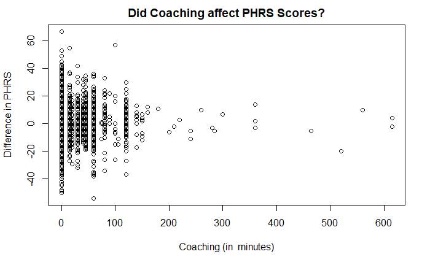

```r
plot(PHRS$TotalCoachingMinutes, PHRS$DifferencePHRS, xlab="Coaching (in  minutes)", main = "Did Coaching affect PHRS Scores?", ylab="Difference in PHRS")
```

```
integer(0)
```

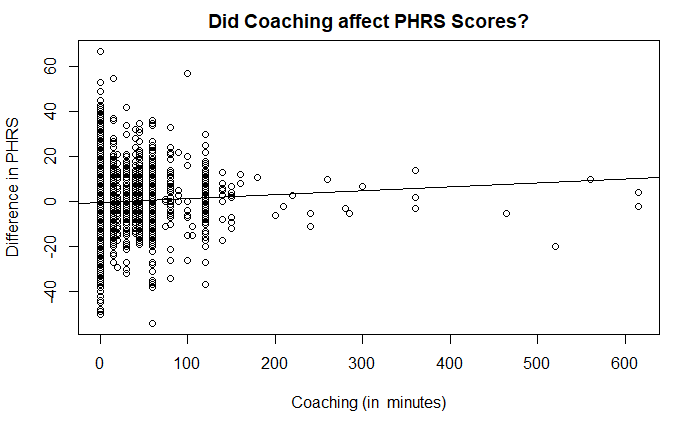

```r
plot(PHRS$TotalCoachingMinutes, PHRS$DifferencePHRS, xlab="Coaching (in  minutes)", main = "Did Coaching affect PHRS Scores?", ylab="Difference in PHRS") + abline(line_1)
```

Note: This is interesting because you would expect that the increase in coaching minutes should increase in increase in PHRS. However a bulk of our data did less than 150 minutes would not have much change.

Lets do the same thing but for x = coaching session, y = difference phrs

```r
line_2 <- lm(DifferencePHRS ~ Coaching, data = PHRS)
summary(line_2)
```

```
Call:
lm(formula = DifferencePHRS ~ Coaching, data = PHRS)

Residuals:
    Min      1Q  Median      3Q     Max
-54.439  -5.490  -0.123   4.510  67.510

Coefficients:
            Estimate Std. Error t value Pr(>|t|)
(Intercept) -0.51031    0.11226  -4.546 5.54e-06 ***
Coaching     0.31652    0.08213   3.854 0.000117 ***
---
Signif. codes:  0 ‘***’ 0.001 ‘**’ 0.01 ‘*’ 0.05 ‘.’ 0.1 ‘ ’ 1

Residual standard error: 10.47 on 9365 degrees of freedom
Multiple R-squared:  0.001584,  Adjusted R-squared:  0.001477
F-statistic: 14.85 on 1 and 9365 DF,  p-value: 0.000117
```

NOTE: slope is still positive

```r
cor.test(Coaching, DifferencePHRS, method=c("pearson", "kendall", "spearman"))
```

```
    Pearson's product-moment correlation

data:  Coaching and DifferencePHRS
t = 3.854, df = 9365, p-value = 0.000117
alternative hypothesis: true correlation is not equal to 0
95 percent confidence interval:
 0.01955768 0.05999665
sample estimates:
       cor
0.03979346
```

p-value is still less than 0.05 = alpha thus there is a significant correlation.

Attempt to plot

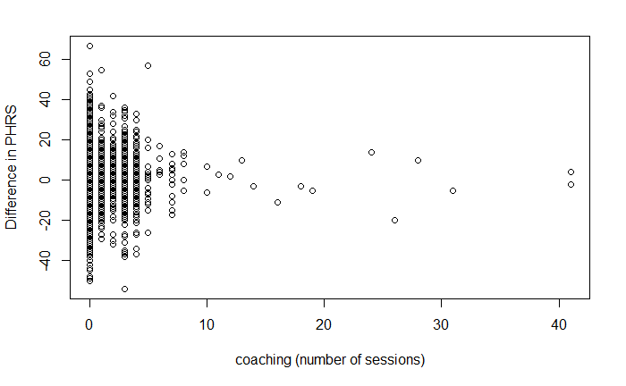

```r
plot(PHRS$Coaching, PHRS$DifferencePHRS, xlab="coaching (number of sessions)", ylab="Difference in PHRS")
```

```
integer(0)
```

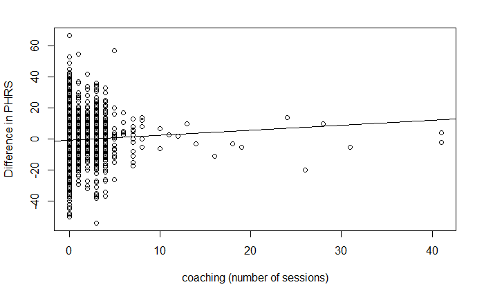

```r
plot(PHRS$Coaching, PHRS$DifferencePHRS, xlab="coaching (number of sessions)", ylab="Difference in PHRS") + abline(line_2)
```

lets look at gender

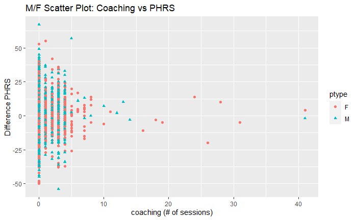

```r
library(ggplot2)

ptype <-rep(NA,length(103))
ptype[PHRS$Gender=="1"] <- "M"
ptype[PHRS$Gender=="2"] <- "F"

qplot(PHRS$Coaching, PHRS$DifferencePHRS,color=ptype,shape=ptype, xlab="coaching (# of sessions)", ylab="Difference PHRS", main = "M/F Scatter Plot: Coaching vs PHRS")
```

After examination of the scatter plot there isn’t obvious differences. The male and Female scores are scattered about with not clear pattern.

**2. Did Coaching affect BMI score? t-test for significance**

- Unlike question one coaching on its affect with PHRS we want BMI to have a negative slope. Example the goal would be if someones pre bmi was 30 and there post score was 25 then the difference (25-30=-5) then that would be good because they improvement. This slope is only -0.0017 so it is again showing very little change from the increase in coaching sessions. Then the slope with coaching (per session) was -0.037.

NOTE: not sure how to factor in that if you have a decrease of score below 18 that also is not good

x = total coaching minutes, y = difference bmi

```r
line_4 <- lm(DifferenceBMI ~ TotalCoachingMinutes, data = PHRS)
summary(line_4)
```

```
Call:
lm(formula = DifferenceBMI ~ TotalCoachingMinutes, data = PHRS)

Residuals:
     Min       1Q   Median       3Q      Max
-16.8012  -0.7012   0.0988   0.7988  12.6988

Coefficients:
                       Estimate Std. Error t value Pr(>|t|)
(Intercept)           0.1012227  0.0181661   5.572 2.59e-08 ***
TotalCoachingMinutes -0.0017041  0.0006933  -2.458    0.014 *
---
Signif. codes:  0 ‘***’ 0.001 ‘**’ 0.01 ‘*’ 0.05 ‘.’ 0.1 ‘ ’ 1

Residual standard error: 1.696 on 9365 degrees of freedom
Multiple R-squared:  0.0006447, Adjusted R-squared:  0.000538
F-statistic: 6.042 on 1 and 9365 DF,  p-value: 0.01399
```

NOTE: negative slope

```r
cor.test(TotalCoachingMinutes, DifferenceBMI, method=c("pearson", "kendall", "spearman"))
```

```
    Pearson's product-moment correlation

data:  TotalCoachingMinutes and DifferenceBMI
t = -2.458, df = 9365, p-value = 0.01399
alternative hypothesis: true correlation is not equal to 0
95 percent confidence interval:
 -0.045619779 -0.005142806
sample estimates:
       cor
-0.0253917
```

Attempt to plot

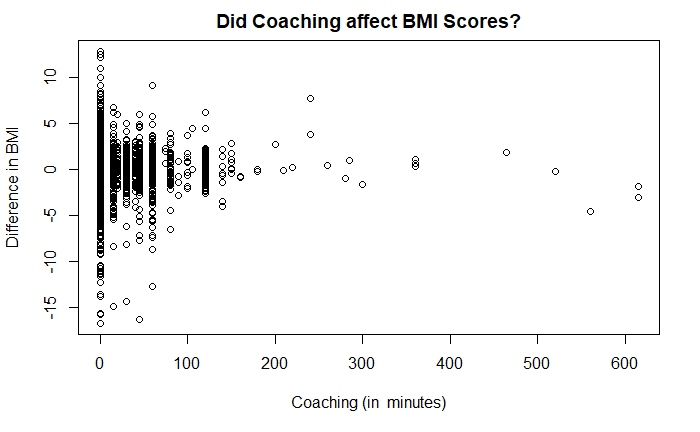

```r
plot(PHRS$TotalCoachingMinutes, PHRS$DifferenceBMI, xlab="Coaching (in  minutes)", main = "Did Coaching affect BMI Scores?", ylab="Difference in BMI")
```

```
integer(0)
```

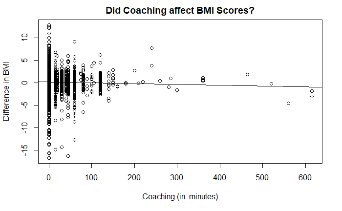

```r
plot(PHRS$TotalCoachingMinutes, PHRS$DifferenceBMI, xlab="Coaching (in  minutes)", main = "Did Coaching affect BMI Scores?",, ylab="Difference in BMI") + abline(line_4)
```

Note: difference in BMI does not mean that you took some sort of coaching. some of the most coaching had the least amount bmi change.

Lets do the same thing but for x = coaching session, y = difference bmi

```r
line_5 <- lm(DifferenceBMI ~ Coaching, data = PHRS)
summary(line_5)
```

```
Call:
lm(formula = DifferenceBMI ~ Coaching, data = PHRS)

Residuals:
    Min      1Q  Median      3Q     Max
-16.803  -0.703   0.097   0.797  12.697

Coefficients:
            Estimate Std. Error t value Pr(>|t|)
(Intercept)  0.10295    0.01818   5.663 1.53e-08 ***
Coaching    -0.03707    0.01330  -2.787  0.00533 **
---
Signif. codes:  0 ‘***’ 0.001 ‘**’ 0.01 ‘*’ 0.05 ‘.’ 0.1 ‘ ’ 1

Residual standard error: 1.696 on 9365 degrees of freedom
Multiple R-squared:  0.0008289, Adjusted R-squared:  0.0007222
F-statistic: 7.769 on 1 and 9365 DF,  p-value: 0.005325
```

NOTE: slope is negative

```r
cor.test(Coaching, DifferenceBMI, method=c("pearson", "kendall", "spearman"))
```

```
    Pearson's product-moment correlation

data:  Coaching and DifferenceBMI
t = -2.7873, df = 9365, p-value = 0.005325
alternative hypothesis: true correlation is not equal to 0
95 percent confidence interval:
 -0.049013603 -0.008544087
sample estimates:
        cor
-0.02879064
```

p-value is still less than 0.05 = alpha thus there is a significant correlation.

Attempt to plot

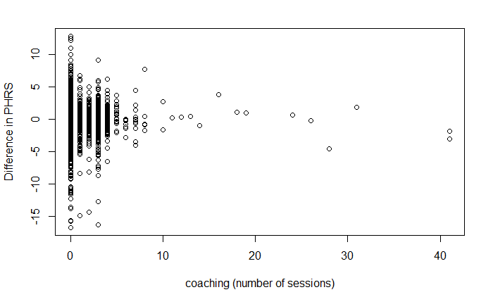

```r
plot(PHRS$Coaching, PHRS$DifferenceBMI, xlab="coaching (number of sessions)", ylab="Difference in PHRS")
```

```
integer(0)
```

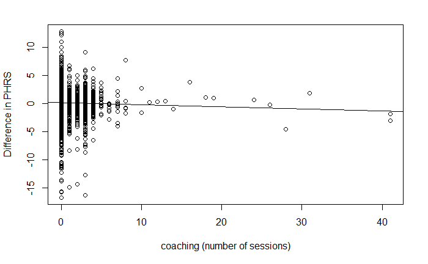

```r
plot(PHRS$Coaching, PHRS$DifferenceBMI, xlab="coaching (number of sessions)", ylab="Difference in PHRS") + abline(line_5)
```

lets look at gender

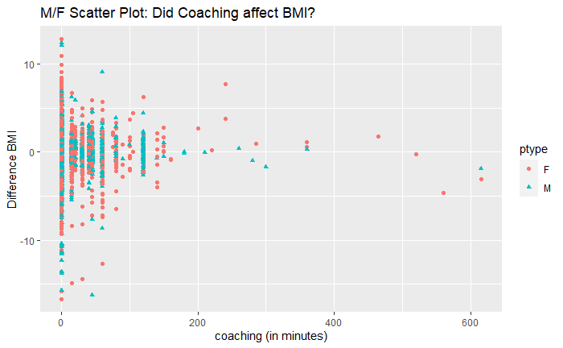

```r
library(ggplot2)

ptype <-rep(NA,length(103))
ptype[PHRS$Gender=="1"] <- "M"
ptype[PHRS$Gender=="2"] <- "F"

qplot(PHRS$TotalCoachingMinutes, PHRS$DifferenceBMI,color=ptype,shape=ptype, xlab="coaching (in minutes)", ylab="Difference BMI", main = "M/F Scatter Plot: Did Coaching affect BMI?")
```

After examination of the scatter plot there isn’t obvious differences. The male and Female scores are scattered about with not clear pattern.

**3. Lets look at if difference in PHRS and difference in BMI are correlated** x = difference PHRS, y = difference phrs

```r
line_3 <- lm(DifferencePHRS ~ DifferenceBMI, data = PHRS)
summary(line_3)
```

```
Call:
lm(formula = DifferencePHRS ~ DifferenceBMI, data = PHRS)

Residuals:
    Min      1Q  Median      3Q     Max
-53.586  -5.174  -0.330   4.452  58.670

Coefficients:
              Estimate Std. Error t value Pr(>|t|)
(Intercept)   -0.23468    0.10377  -2.261   0.0238 *
DifferenceBMI -1.79428    0.06108 -29.376   <2e-16 ***
---
Signif. codes:  0 ‘***’ 0.001 ‘**’ 0.01 ‘*’ 0.05 ‘.’ 0.1 ‘ ’ 1

Residual standard error: 10.03 on 9365 degrees of freedom
Multiple R-squared:  0.08437,   Adjusted R-squared:  0.08427
F-statistic: 862.9 on 1 and 9365 DF,  p-value: < 2.2e-16
```

```r
cor.test(DifferenceBMI, DifferencePHRS, method=c("pearson", "kendall", "spearman"))
```

```
    Pearson's product-moment correlation

data:  DifferenceBMI and DifferencePHRS
t = -29.376, df = 9365, p-value < 2.2e-16
alternative hypothesis: true correlation is not equal to 0
95 percent confidence interval:
 -0.3089007 -0.2718136
sample estimates:
       cor
-0.2904662
```

Attempt to plot

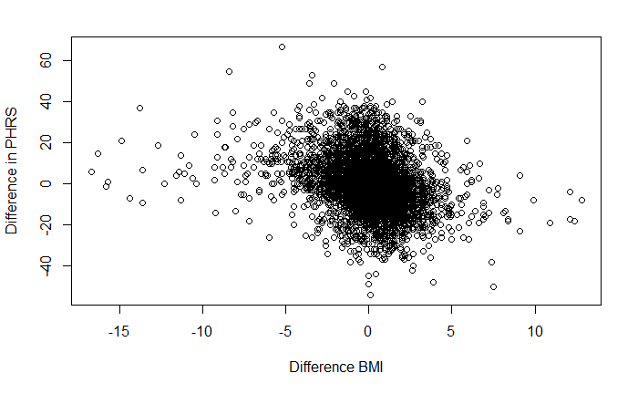

```r
plot(PHRS$DifferenceBMI, PHRS$DifferencePHRS,xlab="Difference BMI", ylab="Difference in PHRS")
```

Note: Something that good is that most the data is centered at 0 to 0 which means that if there is a 0 difference in bmi then there is a 0 difference in PHRS, which makes since. What is hard to understand is that if someone has difference in bmi by 15 or -10 then they still can have 0 change in phrs. This is because there is a lot of factors into PHRS. One thing to point out is that Nicotine Use has a range of 25. While BMI has a change of 15.

lets look at gender

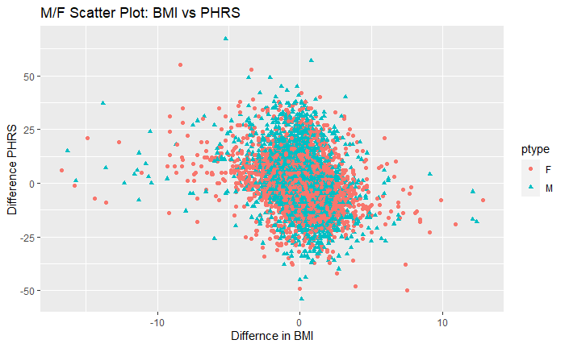

```r
library(ggplot2)

ptype <-rep(NA,length(103))
ptype[PHRS$Gender=="1"] <- "M"
ptype[PHRS$Gender=="2"] <- "F"

qplot(PHRS$DifferenceBMI, PHRS$DifferencePHRS,color=ptype,shape=ptype, xlab="Differnce in BMI", ylab="Difference PHRS", main = "M/F Scatter Plot: BMI vs PHRS")
```

After examination of the scatter plot there isn’t obvious differences. The male and Female scores are scattered about with not clear pattern

**4. Are men more likely to participate in health coaching than women? (or women than men?) Are there subcategories (e.g., men with the BMI over 30 are as likely to participate in health coaching as women with the BMI over 30).**

part a: number of women vs number of men who participate in health coaching - 15.8 percent of Females overall enrolled in coaching vs men 12.3 part b: percent of men and women that participate in health coaching with the subcategories of bmi - the worse the bmi score the more likely a male or female will participate in coaching part c: are men or women more likely to participate in longer amounts of health coaching? - Looks like it starts the highest at 1 (for men) then goes down at 2 then back up 3 (highest for women) coaching sessions. Then only about 15% after 4 coaching sessions. The values are different between male and female. but the trends are the same.

Lets start with the number of women and number of men who participated in health coaching

```r
#number of male
M_count <- sum(PHRS$Gender == "1")
M_count
```

```
[1] 4780
```

```r
#number of male who participated in at least 1 coaching session
Mcoach_count <- sum(PHRS$Gender == "1" & PHRS$Coaching > 0, na.rm=TRUE)
Mcoach_count
```

```
[1] 587
```

```r
#percentage
Mcoach_count / M_count * 100
```

```
[1] 12.28033
```

```r
Mcoach_count / 9366 *100
```

```
[1] 6.26735
```

```r
#number of female
F_count <- sum(PHRS$Gender == "2")
F_count
```

```
[1] 4587
```

```r
#number of female who participated in at least 1 coaching session
Fcoach_count <- sum(PHRS$Gender == "2" & PHRS$Coaching > 0, na.rm=TRUE)
Fcoach_count
```

```
[1] 723
```

```r
#percentage
Fcoach_count / F_count * 100
```

```
[1] 15.76194
```

```r
Fcoach_count / 9366 *100
```

```
[1] 7.719411
```

Male 12.3 percent and female 15.8 percent.

Now lets consider BMI:

According to the HRA Biometric Chart The categories are 18.5-24.9 (healthy) <18.5 or 25-29.9 (unhealthy and almost overweight) 30-34.9 (overweight) 35-39.9 (obese) =>40 (chronically obese)

```r
#categories of bmi that did coaching
#1. 18.5-24.9 (healthy)
coach1_count <- sum(PHRS$Coaching > 0 & PHRS$PREBMI >= 18.5 & PHRS$PREBMI <= 24.9, na.rm=TRUE)
#2. <18.5 or 25-29.9 (unhealthy and almost overweight)
coach2a_count <- sum(PHRS$Coaching > 0 & PHRS$PREBMI < 18.5, na.rm=TRUE)
coach2b_count <- sum(PHRS$Coaching > 0 & PHRS$PREBMI >= 25 & PHRS$PREBMI <= 29.9, na.rm=TRUE)
coach2_count <- coach2a_count+ coach2b_count
#3. 30-34.9 (overweight)
coach3_count <- sum(PHRS$Coaching > 0 & PHRS$PREBMI >= 30 & PHRS$PREBMI <= 34.9, na.rm=TRUE)
#4. 35-39.9 (obese)
coach4_count <- sum(PHRS$Coaching > 0 & PHRS$PREBMI >= 35 & PHRS$PREBMI <= 39.9, na.rm=TRUE)
#5. =>40 (chronically obese)
coach5_count <- sum(PHRS$Coaching > 0 & PHRS$PREBMI >= 40, na.rm=TRUE)
```

```r
#whats the percent of men of a certain bmi that did coaching?
#1. 18.5-24.9 (healthy)
Mcoach1_count <- sum(PHRS$Gender == "1" & PHRS$Coaching > 0 & PHRS$PREBMI >= 18.5 & PHRS$PREBMI < 25.0, na.rm=TRUE)

M1_count <- sum(PHRS$Gender == "1" & PHRS$PREBMI >= 18.5 & PHRS$PREBMI < 25.0, na.rm=TRUE)

Mcoach1_count / M1_count * 100
```

```
[1] 8.460237
```

```r
#2. <18.5 or 25-29.9 (unhealthy and almost overweight)
Mcoach2a_count <- sum(PHRS$Gender == "1" & PHRS$Coaching > 0 & PHRS$PREBMI < 18.5, na.rm=TRUE)
Mcoach2b_count <- sum(PHRS$Gender == "1" & PHRS$Coaching > 0 & PHRS$PREBMI >= 25 & PHRS$PREBMI < 30.0, na.rm=TRUE)
Mcoach2_count <- Mcoach2a_count+Mcoach2b_count

M2a_count <- sum(PHRS$Gender == "1"  & PHRS$PREBMI < 18.5, na.rm=TRUE)
M2b_count <- sum(PHRS$Gender == "1" & PHRS$PREBMI >= 25 & PHRS$PREBMI < 30.0, na.rm=TRUE)
M2_count <- M2a_count+M2b_count

Mcoach2_count / M2_count * 100
```

```
[1] 9.36654
```

```r
#3. 30-34.9 (overweight)
Mcoach3_count <- sum(PHRS$Gender == "1" & PHRS$Coaching > 0 & PHRS$PREBMI >= 30 & PHRS$PREBMI < 35.0, na.rm=TRUE)

M3_count <- sum(PHRS$Gender == "1" & PHRS$PREBMI >= 30 & PHRS$PREBMI < 35.0, na.rm=TRUE)

Mcoach3_count / M3_count * 100
```

```
[1] 12.64205
```

```r
#4. 35-39.9 (obese)
Mcoach4_count <- sum(PHRS$Gender == "1" & PHRS$Coaching > 0 & PHRS$PREBMI >= 35 & PHRS$PREBMI < 40.0, na.rm=TRUE)

M4_count <- sum(PHRS$Gender == "1" & PHRS$PREBMI >= 35 & PHRS$PREBMI < 40.0, na.rm=TRUE)

Mcoach4_count / M4_count * 100
```

```
[1] 19.7615
```

```r
#5. =>40 (chronically obese)
Mcoach5_count <- sum(PHRS$Gender == "1" & PHRS$Coaching > 0 & PHRS$PREBMI >= 40, na.rm=TRUE)

M5_count <- sum(PHRS$Gender == "1" & PHRS$PREBMI >= 40, na.rm=TRUE)

Mcoach5_count / M5_count * 100
```

```
[1] 20.17291
```

In conclusion the worse the BMI score is the more likely a man will complete some coaching

```r
#whats the percent of women of a certain bmi that did coaching?
#1. 18.5-24.9 (healthy)
Fcoach1_count <- sum(PHRS$Gender == "2" & PHRS$Coaching > 0 & PHRS$PREBMI >= 18.5 & PHRS$PREBMI < 25.0, na.rm=TRUE)

F1_count <- sum(PHRS$Gender == "2" & PHRS$PREBMI >= 18.5 & PHRS$PREBMI < 25.0, na.rm=TRUE)

Fcoach1_count / F1_count * 100
```

```
[1] 9.186992
```

```r
#2. <18.5 or 25-29.9 (unhealthy and almost overweight)
Fcoach2a_count <- sum(PHRS$Gender == "2" & PHRS$Coaching > 0 & PHRS$PREBMI < 18.5, na.rm=TRUE)
Fcoach2b_count <- sum(PHRS$Gender == "2" & PHRS$Coaching > 0 & PHRS$PREBMI >= 25 & PHRS$PREBMI < 30.0, na.rm=TRUE)
Fcoach2_count <- Fcoach2a_count+Fcoach2b_count

F2a_count <- sum(PHRS$Gender == "2"  & PHRS$PREBMI < 18.5, na.rm=TRUE)
F2b_count <- sum(PHRS$Gender == "2" & PHRS$PREBMI >= 25 & PHRS$PREBMI < 30.0, na.rm=TRUE)
F2_count <- F2a_count+F2b_count

Fcoach2_count / F2_count * 100
```

```
[1] 11.53534
```

```r
#3. 30-34.9 (overweight)
Fcoach3_count <- sum(PHRS$Gender == "2" & PHRS$Coaching > 0 & PHRS$PREBMI >= 30 & PHRS$PREBMI < 35.0, na.rm=TRUE)

F3_count <- sum(PHRS$Gender == "2" & PHRS$PREBMI >= 30 & PHRS$PREBMI < 35.0, na.rm=TRUE)

Fcoach3_count / F3_count * 100
```

```
[1] 18.23028
```

```r
#4. 35-39.9 (obese)
Fcoach4_count <- sum(PHRS$Gender == "2" & PHRS$Coaching > 0 & PHRS$PREBMI >= 35 & PHRS$PREBMI < 40.0, na.rm=TRUE)

F4_count <- sum(PHRS$Gender == "2" & PHRS$PREBMI >= 35 & PHRS$PREBMI < 40.0, na.rm=TRUE)

Fcoach4_count / F4_count * 100
```

```
[1] 22.20421
```

```r
#5. =>40 (chronically obese)
Fcoach5_count <- sum(PHRS$Gender == "2" & PHRS$Coaching > 0 & PHRS$PREBMI >= 40, na.rm=TRUE)

F5_count <- sum(PHRS$Gender == "2" & PHRS$PREBMI >= 40, na.rm=TRUE)

Fcoach5_count / F5_count * 100
```

```
[1] 28.02102
```

```r
Fcoach5_count
```

```
[1] 160
```

```r
F5_count
```

```
[1] 571
```

```r
M5_count
```

```
[1] 347
```

Ignore: these are test cases

```r
#test: IT WORKS! bmi coaching total=total men coaching
Mcoach1_count+Mcoach2_count+Mcoach3_count+Mcoach4_count+Mcoach5_count-Mcoach_count
```

```
[1] 0
```

```r
#test2: it works
M1_count+M2_count+M3_count+M4_count+M5_count-M_count
```

```
[1] 0
```

```r
#test 3
#(Mcoach1_count+Mcoach2_count+Mcoach3_count+Mcoach4_count+Mcoach5_count)/(M1_count+M2_count+M3_count+M4_count+M5_count) *100
#Mcoach_count / M_count * 100
#test 4
Fcoach1_count+Fcoach2_count+Fcoach3_count+Fcoach4_count+Fcoach5_count-Fcoach_count
```

```
[1] 0
```

```r
F1_count+F2_count+F3_count+F4_count+F5_count-F_count
```

```
[1] 0
```

**5. are men or women more likely to participate in longer amounts of health coaching?** Coaching sessions range from 0 to 41, however most the data is below 10 sessions. lets do 1. 1 2. 2 3. 3 4. 4 5. >= 5

```r
#percent of men and women who participated in one health coaching session
McoachL1_count <- sum(PHRS$Gender == "1" & PHRS$Coaching == 1, na.rm=TRUE)
FcoachL1_count <- sum(PHRS$Gender == "2" & PHRS$Coaching == 1, na.rm=TRUE)

McoachL1_count / Mcoach_count * 100
```

```
[1] 30.83475
```

```r
FcoachL1_count / Fcoach_count * 100
```

```
[1] 30.15214
```

```r
#percent of men and women who participated in 2  health coaching session
McoachL2_count <- sum(PHRS$Gender == "1" & PHRS$Coaching == 2, na.rm=TRUE)
FcoachL2_count <- sum(PHRS$Gender == "2" & PHRS$Coaching == 2, na.rm=TRUE)

McoachL2_count / Mcoach_count * 100
```

```
[1] 22.9983
```

```r
FcoachL2_count / Fcoach_count * 100
```

```
[1] 19.7787
```

```r
#percent of men and women who participated in 3 health coaching session
McoachL3_count <- sum(PHRS$Gender == "1" & PHRS$Coaching == 3, na.rm=TRUE)
FcoachL3_count <- sum(PHRS$Gender == "2" & PHRS$Coaching == 3, na.rm=TRUE)

McoachL3_count / Mcoach_count * 100
```

```
[1] 29.98296
```

```r
FcoachL3_count / Fcoach_count * 100
```

```
[1] 34.16321
```

```r
#percent of men and women who participated in 4 health coaching session
McoachL4_count <- sum(PHRS$Gender == "1" & PHRS$Coaching == 4, na.rm=TRUE)
FcoachL4_count <- sum(PHRS$Gender == "2" & PHRS$Coaching == 4, na.rm=TRUE)

McoachL4_count / Mcoach_count * 100
```

```
[1] 13.96934
```

```r
FcoachL4_count / Fcoach_count * 100
```

```
[1] 9.543568
```

```r
#percent of men and women who participated in 5 or more health coaching session
McoachL5_count <- sum(PHRS$Gender == "1" & PHRS$Coaching >= 5, na.rm=TRUE)
FcoachL5_count <- sum(PHRS$Gender == "2" & PHRS$Coaching >= 5, na.rm=TRUE)

McoachL5_count / Mcoach_count * 100
```

```
[1] 2.214651
```

```r
FcoachL5_count / Fcoach_count * 100
```

```
[1] 6.362379
```

Looks like it starts the highest at 1 then goes down at 2 then back up 3 coaching sessions. Then only about 15% after 4 coaching sessions. The values are different between male and female. but the trends are the same.

**#7 boxplot**

Boxplot of difference in bmi

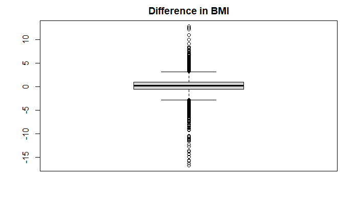

```r
boxplot(PHRS$DifferenceBMI, main= "Difference in BMI")
```

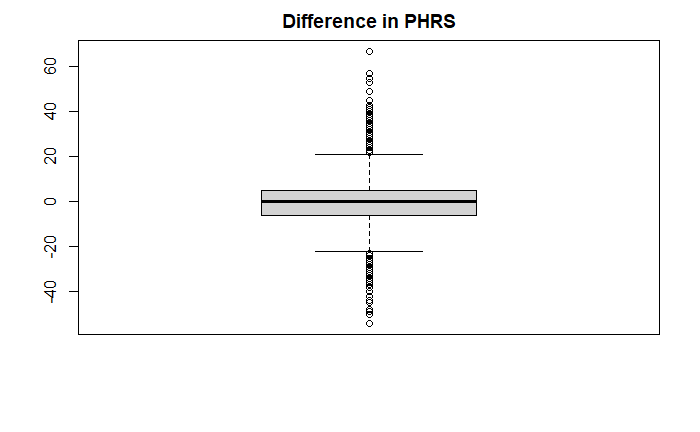

```r
boxplot(PHRS$DifferencePHRS, main = "Difference in PHRS")
```

```r
#percent in bmi category
(M1_count+F1_count) / 9366 *100
```

```
[1] 19.44266
```

```r
(M2_count+F2_count) / 9366 *100
```

```
[1] 32.86355
```

```r
(M3_count+F3_count) / 9366 *100
```

```
[1] 25.04805
```

```r
(M4_count+F4_count) / 9366 *100
```

```
[1] 12.85501
```

```r
(M5_count+F5_count) / 9366 *100
```

```
[1] 9.801409
```